# 从工具理性到价值理性：人机协同决策对能力信任的影响——基于医疗场景的AI视频情景实验证据

Published

May 29, 2026

# 1. 情景视频

| 序号 | 决策模式 | 服务场域 | 任务性质 | 视频链接 |
| --- | --- | --- | --- | --- |
| 情景1 | 仅医生 | 基层医疗机构 | 轻症 | [链接](https://github.com/shumchi/research/raw/refs/heads/main/AI_Medical/Video/基层_医生_轻症_0104.mp4) |
| 情景2 | 仅医生 | 基层医疗机构 | 重症 | [链接](https://github.com/shumchi/research/raw/refs/heads/main/AI_Medical/Video/基层_医生_重症_0104.mp4) |
| 情景3 | 仅医生 | 三级医院 | 轻症 | [链接](https://github.com/shumchi/research/raw/refs/heads/main/AI_Medical/Video/三级医院_医生_轻症_0104.mp4) |
| 情景4 | 仅医生 | 三级医院 | 重症 | [链接](https://github.com/shumchi/research/raw/refs/heads/main/AI_Medical/Video/三级医院_医生_重症_0104.mp4) |
| 情景5 | 先AI后医生 | 基层医疗机构 | 轻症 | [链接](https://github.com/shumchi/research/raw/refs/heads/main/AI_Medical/Video/基层_AI医生_轻症_0104.mp4) |
| 情景6 | 先AI后医生 | 基层医疗机构 | 重症 | [链接](https://github.com/shumchi/research/raw/refs/heads/main/AI_Medical/Video/基层_AI医生_重症_0104.mp4) |
| 情景7 | 先AI后医生 | 三级医院 | 轻症 | [链接](https://github.com/shumchi/research/raw/refs/heads/main/AI_Medical/Video/三级医院_AI医生_轻症_0104.mp4) |
| 情景8 | 先AI后医生 | 三级医院 | 重症 | [链接](https://github.com/shumchi/research/raw/refs/heads/main/AI_Medical/Video/三级医院_AI医生_重症_0104.mp4) |
| 情景9 | 先医生后AI | 基层医疗机构 | 轻症 | [链接](https://github.com/shumchi/research/raw/refs/heads/main/AI_Medical/Video/基层_医生AI_轻症_0104.mp4) |
| 情景10 | 先医生后AI | 基层医疗机构 | 重症 | [链接](https://github.com/shumchi/research/raw/refs/heads/main/AI_Medical/Video/基层_医生AI_重症_0104.mp4) |
| 情景11 | 先医生后AI | 三级医院 | 轻症 | [链接](https://github.com/shumchi/research/raw/refs/heads/main/AI_Medical/Video/三级医院_医生AI_轻症_0104.mp4) |
| 情景12 | 先医生后AI | 三级医院 | 重症 | [链接](https://github.com/shumchi/research/raw/refs/heads/main/AI_Medical/Video/三级医院_医生AI_重症_0104.mp4) |
| 情景13 | 仅AI | 基层医疗机构 | 轻症 | [链接](https://github.com/shumchi/research/raw/refs/heads/main/AI_Medical/Video/基层_AI_轻症_0104.mp4) |
| 情景14 | 仅AI | 基层医疗机构 | 重症 | [链接](https://github.com/shumchi/research/raw/refs/heads/main/AI_Medical/Video/基层_AI_重症_0104.mp4) |
| 情景15 | 仅AI | 三级医院 | 轻症 | [链接](https://github.com/shumchi/research/raw/refs/heads/main/AI_Medical/Video/三级医院_AI_轻症_0104.mp4) |
| 情景16 | 仅AI | 三级医院 | 重症 | [链接](https://github.com/shumchi/research/raw/refs/heads/main/AI_Medical/Video/三级医院_AI_重症_0104.mp4) |

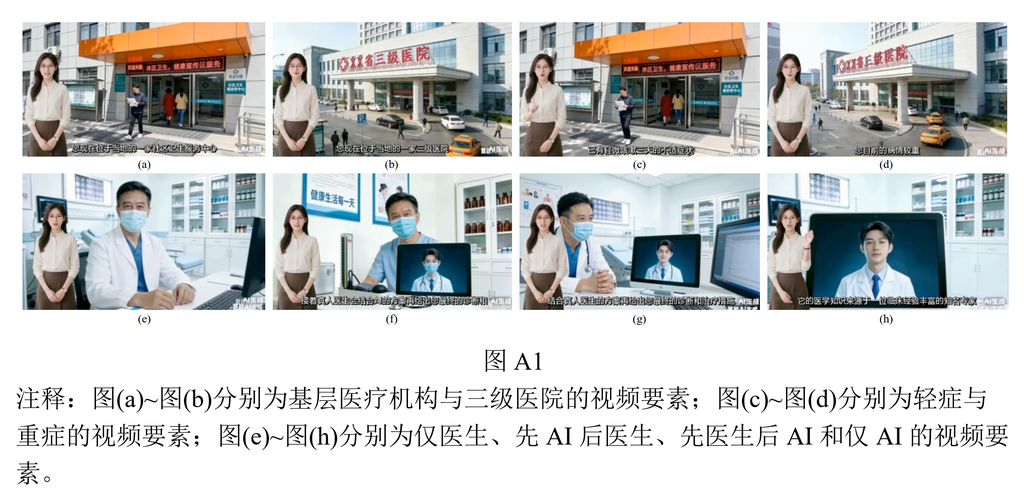

Figure 1: 情景视频截图

# 2. 情景文本

## 情景1：仅医生×基层×轻症

- 您现在位于当地的一家社区卫生服务中心。您目前的病情较轻，已有轻微咳嗽三天的不适症状。接待您的是该中心的一位医生，您会向医生描述病情，提出问题，医生会针对您的病情给出诊断和治疗措施。请根据以上情境，依据您的真实感受进行回答。

## 情景2：仅医生×基层×重症

- 您现在位于当地的一家社区卫生服务中心。您目前的病情较重，已出现高烧、严重呼吸困难、剧烈头痛等不适症状。接待您的是该中心的一位医生，您会向医生描述病情，提出问题，医生会针对您的病情给出诊断和治疗措施。请根据以上情境，依据您的真实感受进行回答。

## 情景3：仅医生×三级×轻症

- 您现在位于当地的一家三级医院。您目前的病情较轻，已有轻微咳嗽三天的不适症状。接待您的是该医院的一位医生，您会向医生描述病情，提出问题，医生会针对您的病情给出诊断和治疗措施。请根据以上情境，依据您的真实感受进行回答。

## 情景4：仅医生×三级×重症

- 您现在位于当地的一家三级医院。您目前的病情较重，已出现高烧、严重呼吸困难、剧烈头痛等不适症状。接待您的是该医院的一位医生，您会向医生描述病情，提出问题，医生会针对您的病情给出诊断和治疗措施。请根据以上情境，依据您的真实感受进行回答。

## 情景5：先AI后医生×基层×轻症

- 您现在位于当地的一家社区卫生服务中心。您目前的病情较轻，已有轻微咳嗽三天的不适症状。接待您的是该中心的一位医生，该中心使用了AI辅助诊断系统。您会向医生描述病情，提出问题，首先由一位拥有丰富临床经验的知名专家的AI医生针对您的病情给出初步的诊断和治疗方案，接着真人医生会结合AI的方案再给出您最终的诊断和治疗措施。请根据以上情境，依据您的真实感受进行回答。

## 情景6：先AI后医生×基层×重症

- 您现在位于当地的一家社区卫生服务中心。您目前的病情较重，已出现高烧、严重呼吸困难、剧烈头痛等不适症状。接待您的是该中心的一位医生，该中心使用了AI辅助诊断系统。您会向医生描述病情，提出问题，首先由一位拥有丰富临床经验的知名专家的AI医生针对您的病情给出初步的诊断和治疗方案，接着真人医生会结合AI的方案再给出您最终的诊断和治疗措施。请根据以上情境，依据您的真实感受进行回答。

- 您现在位于当地的一家三级医院。您目前的病情较轻，已有轻微咳嗽三天的不适症状。接待您的是该医院的一位医生，该医院使用了AI辅助诊断系统。您会向医生描述病情，提出问题，首先由一位拥有丰富临床经验的知名专家的AI医生针对您的病情给出初步的诊断和治疗方案，接着真人医生会结合AI的方案再给出您最终的诊断和治疗措施。请根据以上情境，依据您的真实感受进行回答。

- 您现在位于当地的一家三级医院。您目前的病情较重，已出现高烧、严重呼吸困难、剧烈头痛等不适症状。接待您的是该医院的一位医生，该医院使用了AI辅助诊断系统。您会向医生描述病情，提出问题，首先由一位拥有丰富临床经验的知名专家的AI医生针对您的病情给出初步的诊断和治疗方案，接着真人医生会结合AI的方案再给出您最终的诊断和治疗措施。请根据以上情境，依据您的真实感受进行回答。

## 情景9：先医生后AI×基层×轻症

- 您现在位于当地的一家社区卫生服务中心。您目前的病情较轻，已有轻微咳嗽三天的不适症状。接待您的是该中心的一位医生，该中心使用了AI辅助诊断系统。您会向医生描述病情，提出问题，首先由真人医生针对您的病情给出初步的诊断和治疗方案，接着由一位拥有丰富临床经验的知名专家的AI医生，结合真人医生的方案再给出您最终的诊断和治疗措施。请根据以上情境，依据您的真实感受进行回答。

## 情景10：先医生后AI×基层×重症

- 您现在位于当地的一家社区卫生服务中心。您目前的病情较重，已出现高烧、严重呼吸困难、剧烈头痛等不适症状。接待您的是该中心的一位医生，该中心使用了AI辅助诊断系统。您会向医生描述病情，提出问题，首先由真人医生针对您的病情给出初步的诊断和治疗方案，接着由一位拥有丰富临床经验的知名专家的AI医生，结合真人医生的方案再给出您最终的诊断和治疗措施。请根据以上情境，依据您的真实感受进行回答。

## 情景11：先医生后AI×三级×轻症

- 您现在位于当地的一家三级医院。您目前的病情较轻，已有轻微咳嗽三天的不适症状。接待您的是该医院的一位医生，该医院使用了AI辅助诊断系统。您会向医生描述病情，提出问题，首先由真人医生针对您的病情给出初步的诊断和治疗方案，接着由一位拥有丰富临床经验的知名专家的AI医生，结合真人医生的方案再给出您最终的诊断和治疗措施。请根据以上情境，依据您的真实感受进行回答。

## 情景12：先医生后AI×三级×重症

- 您现在位于当地的一家三级医院。您目前的病情较重，已出现高烧、严重呼吸困难、剧烈头痛等不适症状。接待您的是该医院的一位医生，该医院使用了AI辅助诊断系统。您会向医生描述病情，提出问题，首先由真人医生针对您的病情给出初步的诊断和治疗方案，接着由一位拥有丰富临床经验的知名专家的AI医生，结合真人医生的方案再给出您最终的诊断和治疗措施。请根据以上情境，依据您的真实感受进行回答。

## 情景13：AI×基层×轻症

- 您现在位于当地的一家社区卫生服务中心。目前的病情较轻，已有轻微咳嗽三天的不适症状。接待您的是一位AI医生，它的医学知识来源于一位临床经验丰富的知名专家。具体而言，您会向AI医生描述病情，提出问题，AI医生会针对您的病情给出诊断和治疗措施。请根据以上情境，依据您的真实感受进行回答。

## 情景14：AI×基层×重症

- 您现在位于当地的一家社区卫生服务中心。您目前的病情较重，已出现高烧、严重呼吸困难、剧烈头痛等不适症状。接待您的是一位AI医生，它的医学知识来源于一位临床经验丰富的知名专家。您会向AI医生描述病情，提出问题，AI医生会针对您的病情给出诊断和治疗措施。请根据以上情境，依据您的真实感受进行回答。

## 情景15：AI×三级×轻症

- 您现在位于当地的一家三级医院。目前的病情较轻，已有轻微咳嗽三天的不适症状。接待您的是一位AI医生，它的医学知识来源于一位临床经验丰富的知名专家。具体而言，您会向AI医生描述病情，提出问题，AI医生会针对您的病情给出诊断和治疗措施。请根据以上情境，依据您的真实感受进行回答。

## 情景16：AI×三级×重症

- 您现在位于当地的一家三级医院。您目前的病情较重，已出现高烧、严重呼吸困难、剧烈头痛等不适症状。接待您的是一位AI医生，它的医学知识来源于一位临床经验丰富的知名专家。具体而言，您会向AI医生描述病情，提出问题，AI医生会针对您的病情给出诊断和治疗措施。请根据以上情境，依据您的真实感受进行回答。